# Predicting Multidimensional Poverty using spatial data

Final project - Data Science for Public Policy

Author

Jasmine Jha, David Gentili, Duana Blach, Maddie Dimarco

## Background and Literature Review

We aim to predict Multidimensional Poverty Index (MPI) at a block level in the city of Medellin using Geospatial data. In this attempt, we tried to replicate the paper “Predicting Multidimensional Poverty with Machine Learning Algorithms: An Open Data Source Approach Using Spatial Data” by Guberney Muñetón-Santa and Luis Carlos Manrique-Ruiz.

Specifically, in this project we will train two classes of machine learning models. In the first part we will attempt a regression analysis to try to predict the level of deprivations at the block level. In the second part, we will attempt classification models to try to predict the blocks that are poor or not poor according to the threshold of 33% as we will explained in later parts of this document.

Many economists, e.g., Prof. Amartya Sen, have pointed out that poverty is not just an income-based concept. They have done this through multiple approaches, like the human development income and capability approach (Muñetón-Santa and Manrique-Ruiz, 2023). The shift in calculating poverty has moved beyond income and has incorporated components like health, education, and infrastructure that are crucial for a life with dignity.

However, calculating the MPI can be heavily based on census data that generally is calculated every ten years and is a costly affair (Muñetón-Santa and Manrique-Ruiz, 2023). Measuring poverty and having the capacity to target the poor is critical for effective policy design and implementation. In this sense, “a low-cost method for estimating multidimensional poverty is a crucial tool for qualifying public policy decision-making” (Muñetón-Santa and Manrique-Ruiz, 2023). Moreover, it can help us understand the role these services play in impacting poverty and living standards on individuals and might simultaneously provide governments with a prospective solutions.

The Multidimensional Poverty Index (MPI) is a measure developed by the United Nations Development Programme (UNDP) and the Oxford Poverty and Human Development Initiative (OPHI) to assess acute multidimensional poverty. Unlike traditional poverty measures that focus solely on income, the MPI considers deprivations across three dimensions: health, education, and standard of living. It is built using 10 indicators spanning these three dimensions, each with equal weighting.

To construct the MPI, each person is assigned a deprivation score based on the specific deprivations they face across the 10 indicators. These individual deprivation scores are then weighted and summed to produce a household deprivation score. A household is identified as multidimensionally poor if its deprivation score exceeds the poverty cutoff of 33.3%. This cutoff means that a person is considered multidimensionally poor if they are deprived in at least one-third of the weighted indicators.

The MPI itself is calculated as the product of two measures: the incidence of poverty (H), which is the proportion of people identified as multidimensionally poor, and the intensity of poverty (A), which is the average deprivation score of the poor. By capturing deprivations across multiple dimensions, the MPI provides a more comprehensive understanding of poverty beyond just income levels, enabling targeted policies and interventions to address specific areas of deprivation.

*You can access the full repository using the following link: https://github.com/dag162/ds_final_project*

### Bibliography

Muñetón-Santa, Guberney, and Luis Carlos Manrique-Ruiz. 2023. “Predicting Multidimensional Poverty with Machine Learning Algorithms: An Open Data Source Approach Using Spatial Data.” *Social Sciences* 1-21.

UNDP, and OPHI. 2019. *How to Build a National Multidimensional Poverty Index (MPI): Using the MPI to inform the SDGs.* New York: United Nations Development Programme.

—. n.d. *Multidimensional Poverty and the AF method .* Accessed May Friday, 2024. https://ophi.org.uk/md-poverty-and-AF-method.

```r
#Uploading necessary libraries
library(tidyverse)
library(tidymodels)
library(ranger)
library(sf)
library(patchwork)
library(osmdata)
library(gridExtra)
library(themis)
```

## Data Sources

We will use the Multidimensional Poverty Index (MPI) calculated at the street block level for the city of Medellin from the National Department of Statistics of Colombia (DANE), available in: https://geoportal.dane.gov.co/visipm/. The MPI in this data set will be used as the outcome of interest in our analysis.

```r
col_sf <- read_sf("data/VULNRB_IPMxMZ.shp")

head(col_sf)
```

```
Simple feature collection with 6 features and 8 fields
Geometry type: MULTIPOLYGON
Dimension:     XY
Bounding box:  xmin: -75.54563 ymin: 6.298964 xmax: -75.54212 ymax: 6.302136
Geodetic CRS:  MAGNA-SIRGAS
# A tibble: 6 × 9
  COD_DPTO COD_MPIO COD_DANE         CATEGORIA LABEL   ipm embarazo_a reactivaci
  <chr>    <chr>    <chr>                <dbl> <chr> <dbl> <chr>      <chr>
1 05       05001    050011000000000…         5 Vuln…  39.4 Vulnerabi… elegibili…
2 05       05001    050011000000000…         5 Vuln…  25.9 Vulnerabi… elegibili…
3 05       05001    050011000000000…         2 Vuln…  14.1 Vulnerabi… elegibili…
4 05       05001    050011000000000…         2 Vuln…  26.8 Vulnerabi… elegibili…
5 05       05001    050011000000000…         5 Vuln…  42.2 Vulnerabi… elegibili…
6 05       05001    050011000000000…         2 Vuln…  33.2 Vulnerabi… elegibili…
# ℹ 1 more variable: geometry <MULTIPOLYGON [°]>
```

```r
#Filtering the information for Medellin, and drop variables that we don't need.
med_sf <- col_sf %>%
  filter(COD_MPIO == "05001", ipm !=0, ipm != 100, !is.na(ipm) )%>%
  select(COD_MPIO, ipm, geometry)

med_sf <- med_sf %>%
  mutate(block_id = row_number())
```

As explanatory variables we will attempt to use the distance from each block to public infrastructure in the city. This information is downloaded from Open Street Map (OSM) using the library(osmdata).

```r
med_sf <- med_sf %>%
  st_transform(crs = 4326)

head(med_sf)
```

```
Simple feature collection with 6 features and 3 fields
Geometry type: MULTIPOLYGON
Dimension:     XY
Bounding box:  xmin: -75.54563 ymin: 6.298964 xmax: -75.54212 ymax: 6.302136
Geodetic CRS:  WGS 84
# A tibble: 6 × 4
  COD_MPIO   ipm                                               geometry block_id
  <chr>    <dbl>                                     <MULTIPOLYGON [°]>    <int>
1 05001     39.4 (((-75.54267 6.301819, -75.54262 6.301753, -75.54262 …        1
2 05001     25.9 (((-75.54237 6.299683, -75.54235 6.29965, -75.54235 6…        2
3 05001     14.1 (((-75.5428 6.299641, -75.54277 6.299585, -75.54273 6…        3
4 05001     26.8 (((-75.54386 6.299735, -75.54386 6.299747, -75.54386 …        4
5 05001     42.2 (((-75.54369 6.302136, -75.54369 6.30213, -75.54367 6…        5
6 05001     33.2 (((-75.54536 6.301291, -75.54533 6.301277, -75.54533 …        6
```

```r
bbox1 <- st_bbox(med_sf)

infrastructure <- opq(bbox = bbox1)%>%
  add_osm_features(features = list("amenity" = "school",
                                   "amenity" = "police",
                                   "amenity" = "fire_station",
                                   "amenity" = "bus_station",
                                   "amenity" = "hospital",
                                   "amenity" = "place_of_worship")) %>%
                     osmdata_sf()

#Create the dataframe with the geometry information
infrastructure_points <- bind_rows(
  pluck(infrastructure, "osm_points"),
  st_centroid(pluck(infrastructure, "osm_polygons"))
)

inf_points_clean <- infrastructure_points %>%
  filter(!is.na(name))%>%
  select(osm_id, name, amenity, geometry)
```

The following map shows how the MPI dataset and the infrastrcuture points look like:

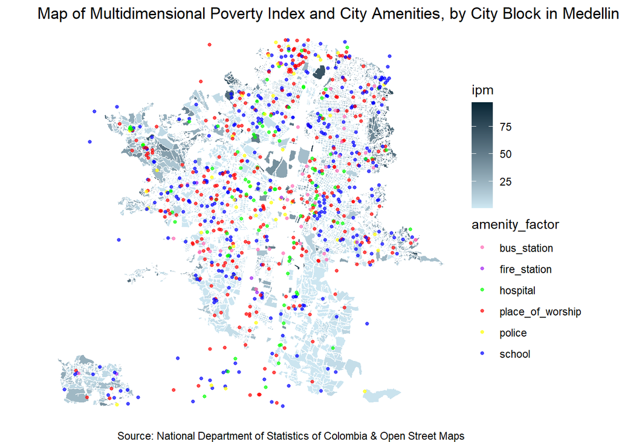

```r
inf_points_clean$amenity_factor <- as.factor(inf_points_clean$amenity)

ggplot() +
  geom_sf(data = med_sf, aes(fill = ipm), color = "white", size = 0.1) +
  scale_fill_gradient(low = "#cfe8f3", high = "#062635") +
  geom_sf(data = inf_points_clean, aes(color = amenity_factor), size = 1, alpha = 0.7) +
  scale_color_manual(values = c(
    school = "blue",
    place_of_worship = "red",
    hospital = "green",
    police = "yellow",
    fire_station = "purple",
    bus_station = "hotpink"
  )) +
  labs(title = "Map of Multidimensional Poverty Index and City Amenities, by City Block in Medellin",
       caption = "Source: National Department of Statistics of Colombia & Open Street Maps") +
  theme_void()
```

In the following section we describe the data wrangling process to obtain the final data set we need to run our machine learning models. The final data set will consist on the MPI per block and the nearest distance of each block to each of the infrastructure points.

## Data Wrangling

In order to conduct the described analysis, we needed to combine the two data sets from DANE and OSM. We worked to create a data set where each block in the city is one row (pulled from the DANE dataset), and the distances from the closest public service (referred to as an amenity) are the columns (calculated using both the DANE and OSM datasets). The amenities categories used are schools, hospitals, police stations, fire stations, bus stops, and places of worship. Hence, the goal was to have, for each block, one column for each category of amenity, with the distance to the closest one.

We tried different approaches to address this goal, including creating a loop, calculating all distances separately, and using “data.table”. However, some approaches didn’t work because it required too much computational power. After multiple trials we figured out a solution which is described below.

We first calculated the centroid of each block as the reference point to the distance calculation using the dataset from the DANE. We organized the next steps by amenity category. For each category, we calculated the distance from each of the amenities to each one of the blocks. Without saving all the calculations, we searched for the smaller distance among the ones calculated. We saved only the smaller distance, representing the closest amenity from each block.

We generated block IDs for each block and divided the calculation into groups by amenity categories with a larger number of units to facilitate running the code. For these categories we merged the groups after calculating them.

After these steps, we had one data frame for each amenity distance calculation. We then combined all the data sets using the left_join command.

Finally, we saved the final data set with only the needed columns and downloaded it separately. The objective of having this final data set saved separately was to ensure that it could be used for the next part of theproject without having to run the time-consuming wrangling code again. These are computational intensive calculations taking over 40 minutes to run on average.

We also ran some initial calculations to ensure there was no missing data, or data that required cleaning from DANE. Since we were the ones creating the main variables (closest amenity distance) from the blocks data and amenities data, we did not have cleaning issues.

**The full code is available on “data_wrangling_medellin.qmd” in the repository for this project. We kept it separate from this file to ensure the viewer could focus only on the analysis, aiming for the best performance on this file.**

```r
#Uploading the final version of the data set for analysis
data_med <- read.csv("data/medellin_dataframe.csv")
```

## Data Analysis: Predicting Models

### Supervised Machine Learning Models - Regression

For this first part we aim to predict Multidimensional Poverty at a block level in the city of Medellin, using Geospatial data. Our supervised machine learning model will attempt to predict the level of MPI per block (our outcome of interest), using regression analysis, based on the distances of each block to all the nearest infrastructure items.

In this case we will choose rmse as our error metric. Considering that people with a score of 33 or higher are poor, and rmse above a 1/3 of that value would be too much for the model to be useful.

#### Set up and Exploratory analysis

1. In the box plot explaining the minimum distance from school, we witness that the not poor are closer to school than the poor. It shows that the not-poor median population is slightly closer to a school than the poor median population.
2. Interestingly, we see that in the second box plot, the poor population are closer to bus stops than not poor population. The median population of poor is slightly closer to bus stops than the median population of not poor.
3. In the third box plot, we witness a stark difference in the closeness from the minimum distance to the fire station between poor and non-poor populations. The poor median population is farther away from fire stations than the not poor median population.
4. The box plot explaining the relation between the population with minimum distance from the hospital shows that the distance is almost equal between the two median populations.
5. In the fifth box plot, we focus on the minimum distance between police stations. Quite interestingly, we see that minimum distance in general is very low for not poor population, unlike the poor population. To point out further, we see no outliers in the distribution of the poor population.
6. The sixth box plot shows the minimum distance from the place of worship. It is almost similar for the two populations in our analysis. To add to it, the minimum distance is quite low for the two median populations.

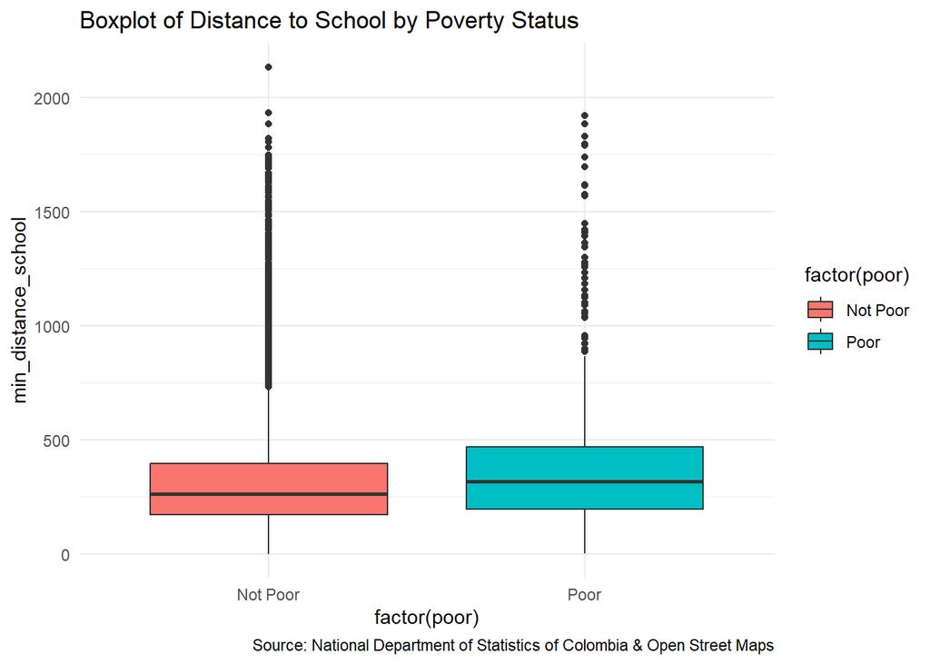

```r
set.seed(456)

# Create a sample for predictive modelling
mpi_split <- initial_split(data_med)

mpi_train <- training(x = mpi_split)
mpi_test <- testing(x = mpi_split)

#EDA on training data

data_med %>%
  mutate(poor = case_when(
    ipm >= 33 ~ "Poor",
    ipm < 33 ~ "Not Poor",
    TRUE ~ NA
  )) %>%
  ggplot(aes(factor(poor), min_distance_school, fill = factor(poor)))+
  geom_boxplot()+
   labs(title = "Boxplot of Distance to School by Poverty Status",
       caption = "Source: National Department of Statistics of Colombia & Open Street Maps") +
  theme_minimal()
```

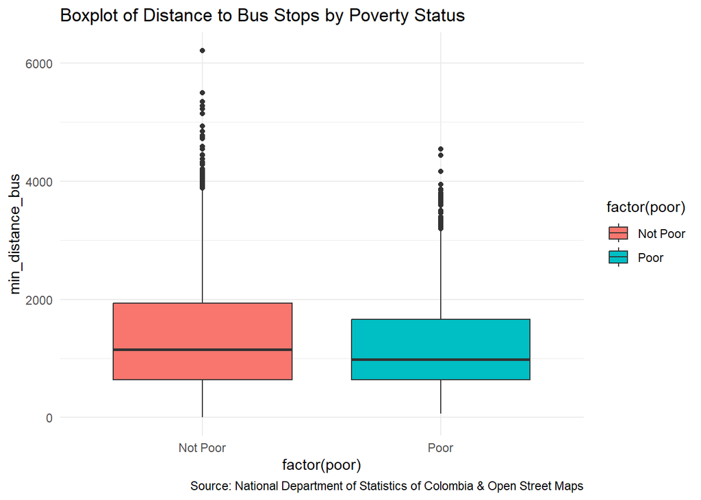

```r
data_med %>%
  mutate(poor = case_when(
    ipm >= 33 ~ "Poor",
    ipm < 33 ~ "Not Poor",
    TRUE ~ NA
  )) %>%
  ggplot(aes(factor(poor), min_distance_bus, fill = factor(poor)))+
  geom_boxplot()+
  labs(title = "Boxplot of Distance to Bus Stops by Poverty Status",
       caption = "Source: National Department of Statistics of Colombia & Open Street Maps") +
  theme_minimal()
```

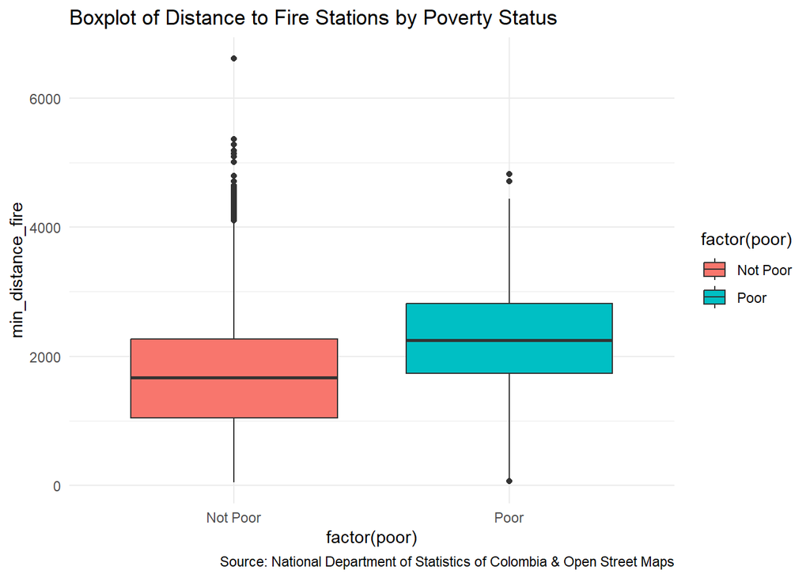

```r
data_med %>%
  mutate(poor = case_when(
    ipm >= 33 ~ "Poor",
    ipm < 33 ~ "Not Poor",
    TRUE ~ NA
  )) %>%
  ggplot(aes(factor(poor), min_distance_fire, fill = factor(poor)))+
  geom_boxplot()+
  labs(title = "Boxplot of Distance to Fire Stations by Poverty Status",
       caption = "Source: National Department of Statistics of Colombia & Open Street Maps") +
  theme_minimal()
```

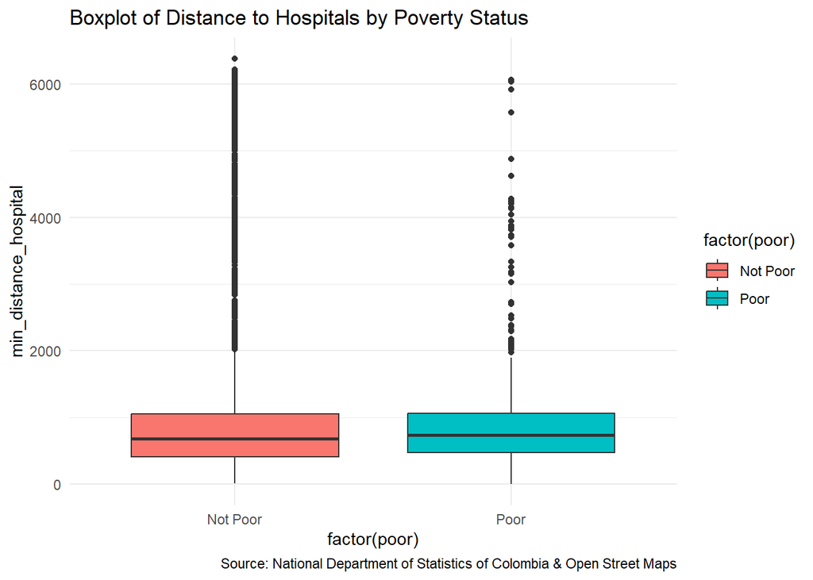

```r
data_med %>%
  mutate(poor = case_when(
    ipm >= 33 ~ "Poor",
    ipm < 33 ~ "Not Poor",
    TRUE ~ NA
  )) %>%
  ggplot(aes(factor(poor), min_distance_hospital, fill = factor(poor)))+
  geom_boxplot()+
  labs(title = "Boxplot of Distance to Hospitals by Poverty Status",
       caption = "Source: National Department of Statistics of Colombia & Open Street Maps") +
  theme_minimal()
```

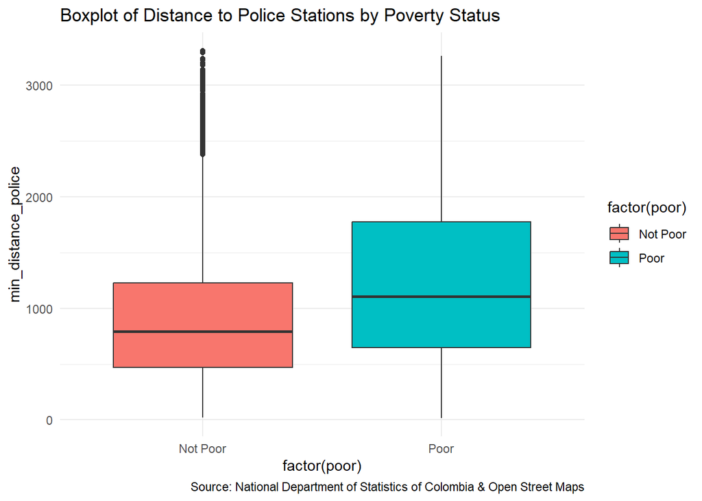

```r
data_med %>%
  mutate(poor = case_when(
    ipm >= 33 ~ "Poor",
    ipm < 33 ~ "Not Poor",
    TRUE ~ NA
  )) %>%
  ggplot(aes(factor(poor), min_distance_police, fill = factor(poor)))+
  geom_boxplot()+
  labs(title = "Boxplot of Distance to Police Stations by Poverty Status",
       caption = "Source: National Department of Statistics of Colombia & Open Street Maps") +
  theme_minimal()
```

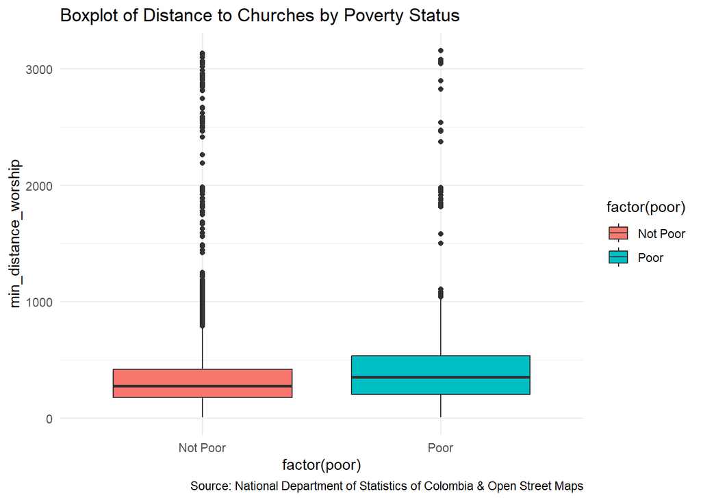

```r
data_med %>%
  mutate(poor = case_when(
    ipm >= 33 ~ "Poor",
    ipm < 33 ~ "Not Poor",
    TRUE ~ NA
  )) %>%
  ggplot(aes(factor(poor), min_distance_worship, fill = factor(poor)))+
  geom_boxplot()+
  labs(title = "Boxplot of Distance to Churches by Poverty Status",
       caption = "Source: National Department of Statistics of Colombia & Open Street Maps") +
  theme_minimal()
```

#### Training and selecting the best model

```r
#Resampling
set.seed(10624)

folds <- vfold_cv(mpi_train, v = 10)
```

```r
# Specifications

#linear reg specification
lm_spec <- linear_reg()%>%
  set_engine("lm") %>%
  set_mode("regression")

#KNN specification
knn_spec <- nearest_neighbor(neighbors = tune()) %>%
  set_engine(engine = "kknn") %>%
  set_mode(mode = "regression")

#Random forest specification

rf_spec <- rand_forest(
  trees = 1000,
  min_n = 10) %>%
  set_mode("regression")%>%
  set_engine("ranger")
```

```r
# Recipes

#Linear regression recipe

lm_rec <- recipe(ipm ~ ., mpi_train)%>%
  step_rm(block_id)%>%
  step_zv(all_predictors())%>%
  step_impute_linear(all_predictors())%>%
  step_corr(all_predictors())

#knn recipe

knn_rec <- recipe(ipm ~ ., mpi_train)%>%
  step_rm(block_id)%>%
  step_zv(all_predictors())%>%
  step_normalize(all_predictors())

#Rand forest recipe

general_rec <- recipe(ipm ~ ., mpi_train)%>%
  step_rm(block_id)
```

```r
##Workflows

lm_workflow <- workflow() %>%
  add_recipe(lm_rec)%>%
  add_model(lm_spec)

knn_workflow <- workflow() %>%
  add_recipe(knn_rec)%>%
  add_model(knn_spec)

rf_workflow <- workflow() %>%
  add_recipe(general_rec)%>%
  add_model(rf_spec)
```

To collect the metrics we used the optimal paramenters from KNN, i.e., 15 neighbours.

```r
##Fiting and hyperparameter tuning

#Fitting regression model using v-fold re sampling method
lm_fit_rs <- lm_workflow %>%
  fit_resamples(resamples = folds,
                control = control_resamples(save_pred = TRUE),
                metrics = metric_set(rmse, rsq))

#Fiting and tuning knn
knn_grid <- grid_regular(neighbors(range = c(1, 15)), levels = 10)

knn_res <- knn_workflow %>%
  tune_grid(resamples = folds,
            grid = knn_grid,
            control = control_grid(save_pred = TRUE),
            metrics = metric_set(rmse, rsq))

knn_best <- knn_res %>%
  select_best(metric = "rmse") #15 neighbors

###Fiting again###
knn_spec_tune <- nearest_neighbor(neighbors = 15) %>%
  set_engine(engine = "kknn") %>%
  set_mode(mode = "regression")

knn_tune_workflow <- workflow() %>%
  add_recipe(knn_rec)%>%
  add_model(knn_spec_tune)

knn_fit_tune_rs <- knn_tune_workflow %>%
  fit_resamples(resamples = folds,
                control = control_resamples(save_pred = TRUE),
                metrics = metric_set(rmse, rsq))

#Fiting random forest
rf_fit_rs <- rf_workflow %>%
  fit_resamples(resamples = folds,
                control = control_resamples(save_pred = TRUE),
                metrics = metric_set(rmse, rsq))
```

We select the KNN as the best model based on rmse. In the linear regression model we see that rmse’s mean is 13.93781553 and the standard error is 0.110941174. In the KNN model the rmse mean value is 11.2959111 and the standard error is 0.13778253. In the random forest model, the mean value for rmse is 11.3970902 and the standard error is 0.14735739.

```r
###Collecting metrics###
lm_metrics <- collect_metrics(lm_fit_rs)
print(lm_metrics)
```

```
# A tibble: 2 × 6
  .metric .estimator    mean     n std_err .config
  <chr>   <chr>        <dbl> <int>   <dbl> <chr>
1 rmse    standard   13.9       10 0.111   Preprocessor1_Model1
2 rsq     standard    0.0897    10 0.00656 Preprocessor1_Model1
```

```r
knn_metrics <- collect_metrics(knn_fit_tune_rs)
print(knn_metrics)
```

```
# A tibble: 2 × 6
  .metric .estimator   mean     n std_err .config
  <chr>   <chr>       <dbl> <int>   <dbl> <chr>
1 rmse    standard   11.3      10  0.138  Preprocessor1_Model1
2 rsq     standard    0.403    10  0.0101 Preprocessor1_Model1
```

```r
rf_metrics <- collect_metrics(rf_fit_rs)
print(rf_metrics)
```

```
# A tibble: 2 × 6
  .metric .estimator   mean     n std_err .config
  <chr>   <chr>       <dbl> <int>   <dbl> <chr>
1 rmse    standard   11.4      10  0.147  Preprocessor1_Model1
2 rsq     standard    0.394    10  0.0125 Preprocessor1_Model1
```

From here we proceed with the KNN model to finalize the prediction.

#### Final fitting and prediction

```r
knn_final <- finalize_workflow(knn_workflow,
                               parameters = knn_best)

knn_final_fit <-knn_final %>%
  fit(data = mpi_train)

knn_predictions <- knn_final_fit%>%
  predict(new_data = mpi_test)

knn_rmse_final <- bind_cols(
  mpi_test %>% select(ipm),
  knn_predictions %>% select(.pred)) %>%
  rmse(truth = ipm, estimate = .pred)

knn_rmse_final
```

```
# A tibble: 1 × 3
  .metric .estimator .estimate
  <chr>   <chr>          <dbl>
1 rmse    standard        11.5
```

Implementation of the final model

```r
mpi_implement_predict <- knn_final_fit %>%
  predict(data_med)

mpi_implement_predict_final <- bind_cols(
  data_med,
  mpi_implement_predict %>% select(.pred))

head(mpi_implement_predict_final)
```

```
  block_id  ipm min_distance_school min_distance_bus min_distance_fire
1        1 39.4            403.3393         755.1030          3875.037
2        2 25.9            216.3104         542.9941          3837.381
3        3 14.1            250.5177         549.1959          3810.580
4        4 26.8            368.7848         645.2458          3762.137
5        5 42.2            534.2343         856.7014          3736.222
6        6 33.2            593.9645         841.4657          3563.118
  min_distance_hospital min_distance_police min_distance_worship    .pred
1              893.0054            880.9119             354.3527 28.17512
2              689.7253            711.9193             482.2383 20.70192
3              707.2494            745.6875             451.1030 20.11481
4              814.9507            863.6428             336.5529 27.04651
5             1012.7174           1022.9701             204.9766 36.20974
6             1024.6798           1088.1177             141.4768 25.02577
```

#### Results

To analyze the results we will look at the original dataset of MPI per block of Medellin that contains the shape files to understand visually how our model performed in comparison to the real values. We also need to bind the predicted MPI to the original Medellin data set to make a visual comparisons.

```r
med_comparison <- bind_cols(
  med_sf,
  mpi_implement_predict %>% select(.pred))

#calculating the absolute difference between predicted and actual MPI.
med_comparison2 <- med_comparison %>%
  mutate(diff_pmi = abs(ipm - .pred))

head(med_comparison2)
```

```
Simple feature collection with 6 features and 5 fields
Geometry type: MULTIPOLYGON
Dimension:     XY
Bounding box:  xmin: -75.54563 ymin: 6.298964 xmax: -75.54212 ymax: 6.302136
Geodetic CRS:  WGS 84
# A tibble: 6 × 6
  COD_MPIO   ipm                                geometry block_id .pred diff_pmi
  <chr>    <dbl>                      <MULTIPOLYGON [°]>    <int> <dbl>    <dbl>
1 05001     39.4 (((-75.54267 6.301819, -75.54262 6.301…        1  28.2   11.2
2 05001     25.9 (((-75.54237 6.299683, -75.54235 6.299…        2  20.7    5.20
3 05001     14.1 (((-75.5428 6.299641, -75.54277 6.2995…        3  20.1    6.01
4 05001     26.8 (((-75.54386 6.299735, -75.54386 6.299…        4  27.0    0.247
5 05001     42.2 (((-75.54369 6.302136, -75.54369 6.302…        5  36.2    5.99
6 05001     33.2 (((-75.54536 6.301291, -75.54533 6.301…        6  25.0    8.17
```

We plot a map of Medellin with the actual MPI per block and another with the predicted MPI. We have to remember that an MPI of 33 or above is considered poor, and the higher it goes the higher the severity of poverty. In that sense, the more intense the color of the block, the poorer they are in MPI measure.

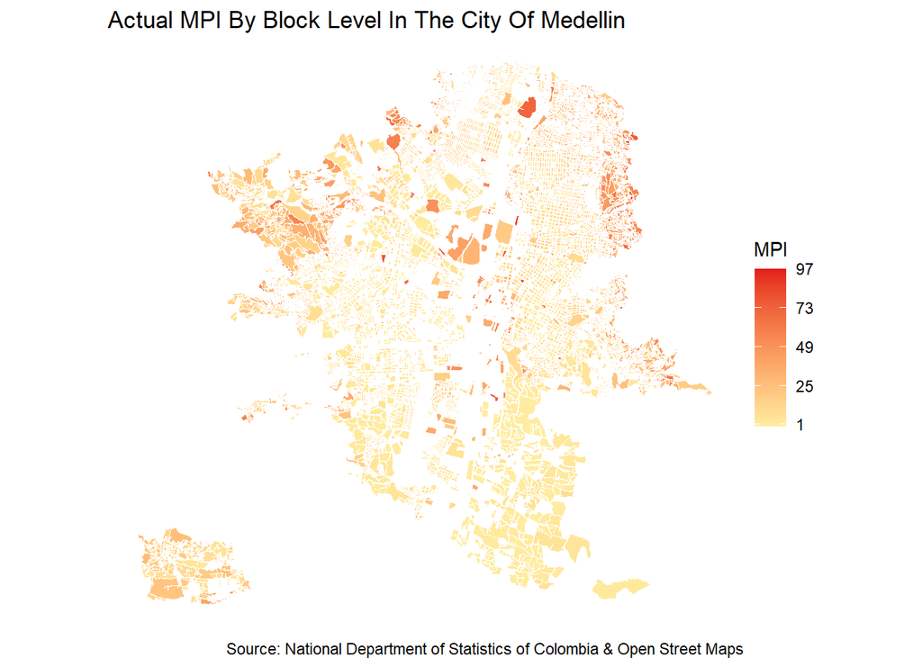

```r
# Calculate the overall range for both variables
overall_range <- range(c(med_comparison2$ipm, med_comparison2$.pred))

# Define breaks for the color scale
breaks <- seq(ceiling(overall_range[1]), floor(overall_range[2]), length.out = 5)

# Plot 1: Contour Map for ipm variable
ggplot(med_comparison2) +
  geom_sf(aes(fill = ipm), color = "white", size = 0.1) +
  scale_fill_gradient(
    low = "#FFEDA0",  # Light yellow
    high = "#E31A1C", # Red
    limits = overall_range,  # Set the limits to ensure consistency
    breaks = breaks,
    guide = guide_colorbar(title = "MPI")) +
  labs(title = "Actual MPI By Block Level In The City Of Medellin",  caption = "Source: National Department of Statistics of Colombia & Open Street Maps") +
  theme_void()
```

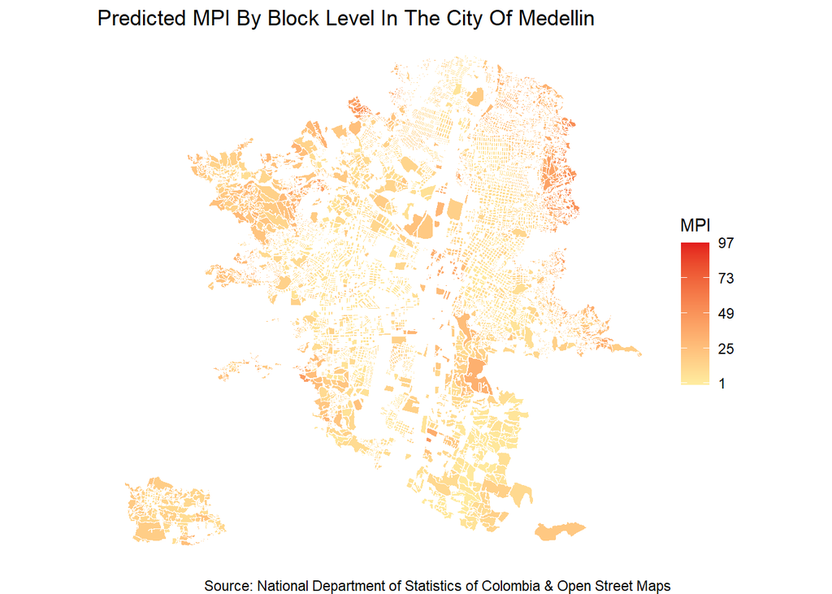

```r
# Plot 2: Contour Map for .pred variable
ggplot(med_comparison2) +
  geom_sf(aes(fill = .pred), color = "white", size = 0.1) +
  scale_fill_gradient(
    low = "#FFEDA0",  # Light yellow
    high = "#E31A1C", # Red
    limits = overall_range,  # Set the limits to ensure consistency
    breaks = breaks,
    guide = guide_colorbar(title = "MPI")) +
  labs(title = "Predicted MPI By Block Level In The City Of Medellin",  caption = "Source: National Department of Statistics of Colombia & Open Street Maps") +
  theme_void()
```

We also calculated the absolute difference on MPIs between the actual values and the predicted ones. In this case, those blocs closer to a blue color have the biggest difference, meaning they have the highest error in prediction. In contrast, the blocks closer to yellow have a lower error in the prediction.

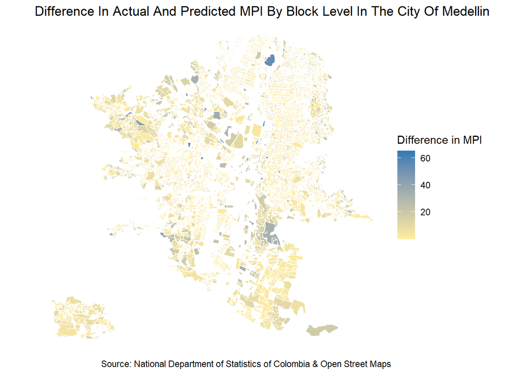

```r
# Difference in actual and predicted MPI
ggplot() +
  geom_sf(
    data = med_comparison2,
    aes(fill = diff_pmi),
    color = "white",
    size = 0.1
  ) +
  scale_fill_gradient(
    low = "#FFEDA0",
    high = "#2C7BB6",
    guide = guide_colorbar(title = "Difference in MPI")
  ) +
  labs(
    title = "Difference In Actual And Predicted MPI By Block Level In The City Of Medellin",
    caption = "Source: National Department of Statistics of Colombia & Open Street Maps"
  ) +
  theme_void()
```

Finally, we wanted to understand the distribution of the errors in our predictions to understand how far away they are form the actual values. We can see how the bulk of the differences are between 1 and 6 points in absolute terms. That means that, the majority of the errors in our predictions are values that are between 1 and 6 points higher or lower than the actual value.

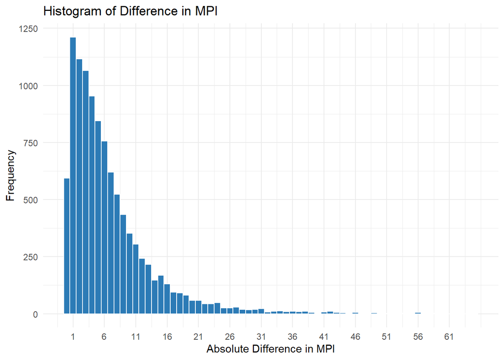

```r
# histogram

# Calculate the range of the diff_pmi variable
diff_pmi_range <- range(med_comparison2$diff_pmi)

# Define breaks with fewer intervals
custom_breaks <- seq(ceiling(diff_pmi_range[1]), floor(diff_pmi_range[2]), by = 5)

histogram <- ggplot(med_comparison2, aes(x = diff_pmi)) +
  geom_histogram(binwidth = 1, fill = "#2C7BB6", color = "white") +
  labs(
    x = "Absolute Difference in MPI",
    y = "Frequency",
    title = "Histogram of Difference in MPI"
  ) +
  scale_x_continuous(breaks = custom_breaks) +
  theme_minimal()

histogram
```

### Supervised Machine Learning Models - Classification

For this first part we aim to predict Multidimensional Poverty at a block level in the city of Medellin, using Geospatial data. Our supervised machine learning model will do a binary classification to predict poverty status (either poor or non-poor) by block.

We will do a classification model by creating a new variable that is either poor or not poor. Poor is classified when IPM >=33 and not poor when IPM<33. We will then run several models to predict whether each block is poor or not poor based on the distances to each of the amenities.

```r
data_med <- data_med %>%
  mutate(poor = ifelse(ipm >= 33, "poor", "not poor"))

set.seed(20220412)

med_split <-
  initial_split(data = data_med, prop = 0.8)

med_train <-
  training(x= med_split)

med_test <-
  testing(x=med_split)
```

#### Exploratory Data Analysis

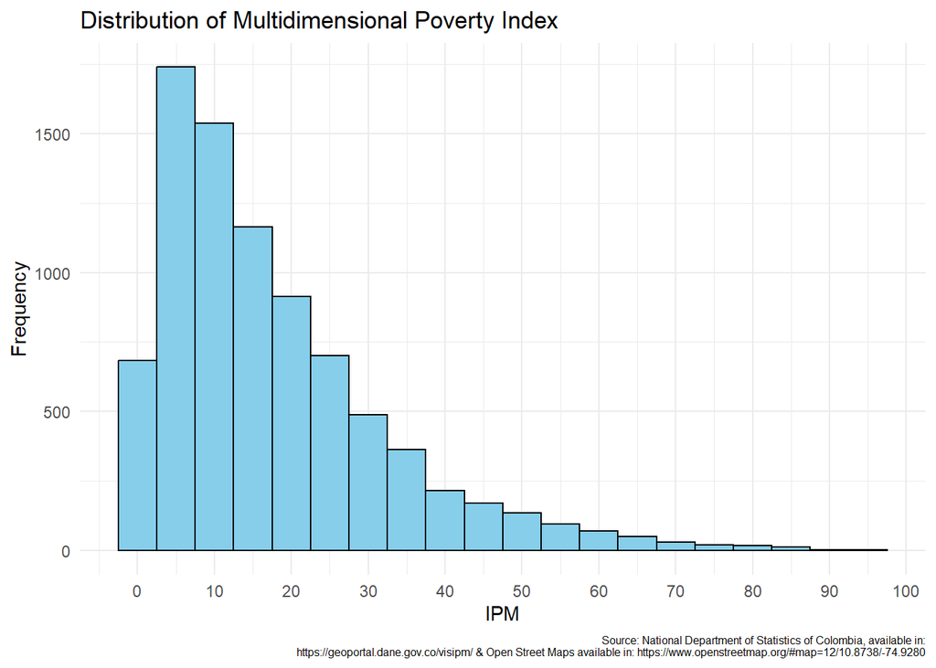

```r
ggplot(med_train, aes(x = ipm)) +
  geom_histogram(binwidth = 5, fill = "skyblue", color = "black") +
  labs(title = "Distribution of Multidimensional Poverty Index", x = "IPM", y = "Frequency",
       caption = "Source: National Department of Statistics of Colombia, available in:
https://geoportal.dane.gov.co/visipm/ & Open Street Maps available in: https://www.openstreetmap.org/#map=12/10.8738/-74.9280") +
  scale_x_continuous(breaks = seq(0, 100, by = 10)) +
  theme_minimal() +
  theme(plot.caption = element_text(size = 6))
```

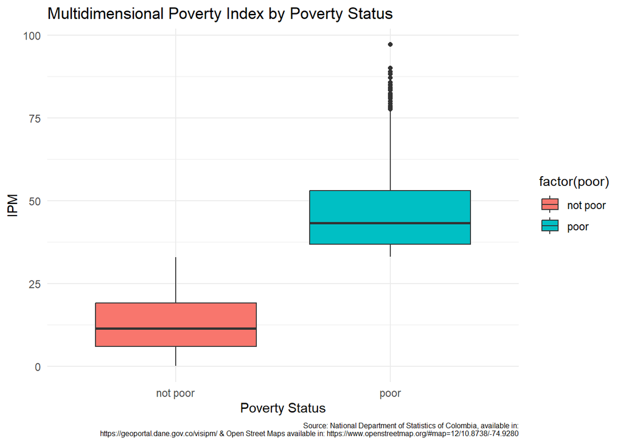

```r
ggplot(med_train, aes(x = factor(poor), y = ipm, fill = factor(poor))) +
  geom_boxplot() +
  labs(title = "Multidimensional Poverty Index by Poverty Status", x = "Poverty Status", y = "IPM",
       caption = "Source: National Department of Statistics of Colombia, available in:
https://geoportal.dane.gov.co/visipm/ & Open Street Maps available in: https://www.openstreetmap.org/#map=12/10.8738/-74.9280") +
   theme_minimal() +
  theme(plot.caption = element_text(size = 6))
```

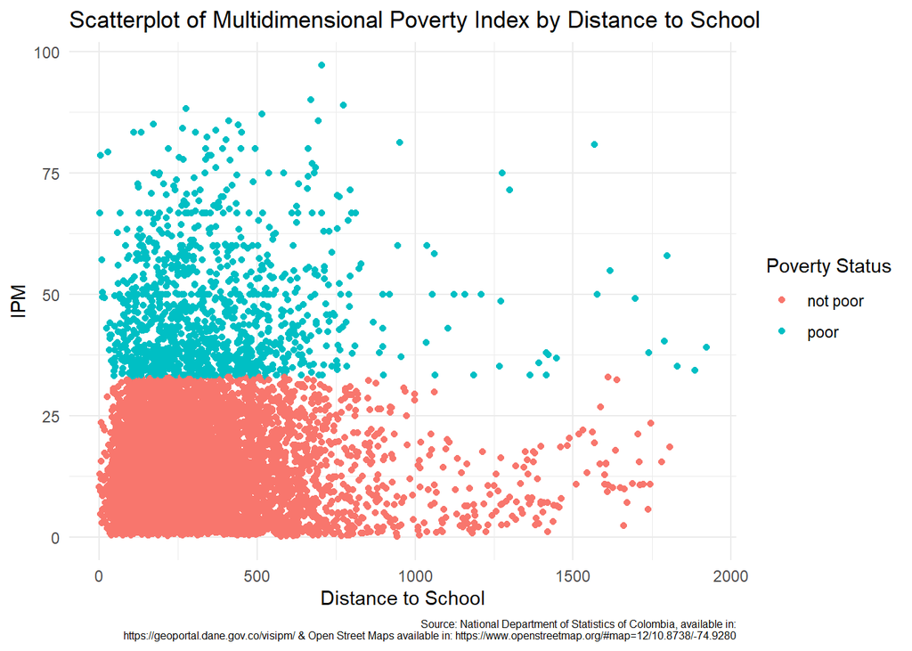

```r
ggplot(med_train, aes(x = min_distance_school, y = ipm, color = factor(poor))) +
  geom_point() +
  labs(title = "Scatterplot of Multidimensional Poverty Index by Distance to School", x = "Distance to School", y = "IPM", color = "Poverty Status",
       caption = "Source: National Department of Statistics of Colombia, available in:
https://geoportal.dane.gov.co/visipm/ & Open Street Maps available in: https://www.openstreetmap.org/#map=12/10.8738/-74.9280") +
   theme_minimal() +
  theme(plot.caption = element_text(size = 6))
```

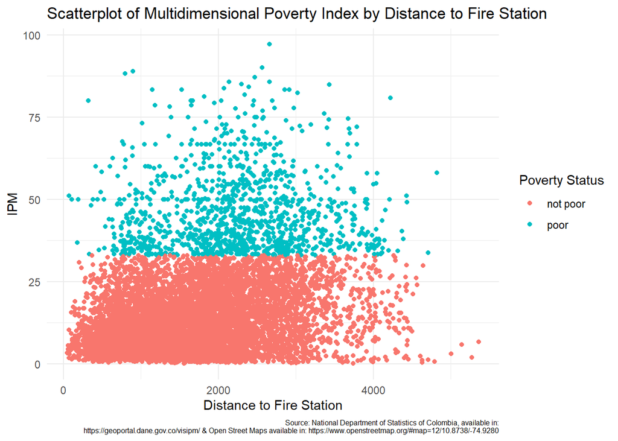

```r
ggplot(med_train, aes(x = min_distance_fire, y = ipm, color = factor(poor))) +
  geom_point() +
  labs(title = "Scatterplot of Multidimensional Poverty Index by Distance to Fire Station", x = "Distance to Fire Station", y = "IPM", color = "Poverty Status",
       caption = "Source: National Department of Statistics of Colombia, available in:
https://geoportal.dane.gov.co/visipm/ & Open Street Maps available in: https://www.openstreetmap.org/#map=12/10.8738/-74.9280") +
   theme_minimal() +
   theme(plot.caption = element_text(size = 6))
```

Using the first plot, we can see the distribution of IPM scores from 0 to 100. We see that the overall distribution is right tailed, with a significant portion of the blocks scoring below 20 and a decreasing number scoring above that. The second plot shows us the average scores once we make the distinction between poor and not poor using the IPM score of 33 as the threshold. We can see the overall average IPM score for the poor vs. the non-poor. We can see that the averages are relatively far apart in terms of IPM score, which we hope will make the model more successful (rather than scores all being clustered closer to 33, which would make the prediction harder.

The next twp plots show the difference in distances between poor and not poor to schools and fire stations. We can see that the difference in distance to schools is very minimal, with the poor only slightly further away than the non poor (which can also be seen in the boxplots from the initial exploratory analysis). This difference is a bit larger for the fire stations, with the poor further away, though the confidence intervals are overlapping. The fact that both distances are relatively close together for the two groups means the predictive strength of our model may not be as good as we hoped.

#### Training and selecting the best model

```r
# Model 1 - KNN

class_folds <- vfold_cv(med_train, v = 10)


med_knn_spec <- nearest_neighbor(weight_func = "rectangular", neighbors = tune()) %>%
  set_engine("kknn") %>%
  set_mode("classification")

med_knn_rec <- recipe(poor ~ ., data = med_train) %>%
  step_rm(block_id, ipm) %>%
  step_zv(all_predictors()) %>%
  step_normalize(all_numeric_predictors())

med_knn_workflow <- workflow() %>%
  add_recipe(med_knn_rec) %>%
  add_model(med_knn_spec)

med_knn_grid <- grid_regular(neighbors(range = c(1, 15)), levels = 10)


med_knn_res <- med_knn_workflow %>%
  tune_grid(resamples = class_folds,
            control = control_grid(save_pred = TRUE),
            metrics = metric_set(accuracy, sensitivity, specificity))

med_knn_best <- select_best(med_knn_res, metric = "sensitivity")

med_knn_best
```

```
# A tibble: 1 × 2
  neighbors .config
      <int> <chr>
1        13 Preprocessor1_Model09
```

```r
# The best parameter was 13 neighbors

med_knn_spec_tune <- nearest_neighbor(neighbors = 13) %>%
  set_engine(engine = "kknn") %>%
  set_mode(mode = "regression")

med_knn_spec_tune <- nearest_neighbor(weight_func = "rectangular", neighbors = med_knn_best$neighbors) %>%
  set_engine("kknn") %>%
  set_mode("classification")

med_knn_tune_workflow <- workflow() %>%
  add_recipe(med_knn_rec) %>%
  add_model(med_knn_spec_tune)

med_knn_fit_tune_rs <- med_knn_tune_workflow %>%
  fit_resamples(resamples = class_folds,
                control = control_resamples(save_pred = TRUE),
                metrics = metric_set(accuracy, sensitivity, specificity))

med_knn_metrics <- collect_metrics(med_knn_fit_tune_rs)
print(med_knn_metrics)
```

```
# A tibble: 3 × 6
  .metric     .estimator  mean     n  std_err .config
  <chr>       <chr>      <dbl> <int>    <dbl> <chr>
1 accuracy    binary     0.874    10 0.00457  Preprocessor1_Model1
2 sensitivity binary     0.976    10 0.000878 Preprocessor1_Model1
3 specificity binary     0.235    10 0.0150   Preprocessor1_Model1
```

```r
# Logistic model

# Logistic regression model specification
logistic_spec <- logistic_reg(mode = "classification") %>%
  set_engine("glm")

# Data preprocessing recipe
logistic_rec <- recipe(poor ~ ., data = med_train) %>%
  step_rm(block_id, ipm) %>%
  step_zv(all_predictors()) %>%
  step_normalize(all_numeric_predictors())

# Create workflow
logistic_workflow <- workflow() %>%
  add_recipe(logistic_rec) %>%
  add_model(logistic_spec)

# Fit the model to each resample
logistic_fit_resamples <- logistic_workflow %>%
  fit_resamples(resamples = class_folds,
                control = control_resamples(save_pred = TRUE),
                metrics = metric_set(accuracy, specificity, sensitivity))

# Collect and print the evaluation metrics
logistic_metrics <- collect_metrics(logistic_fit_resamples)
print(logistic_metrics)
```

```
# A tibble: 3 × 6
  .metric     .estimator   mean     n  std_err .config
  <chr>       <chr>       <dbl> <int>    <dbl> <chr>
1 accuracy    binary     0.859     10 0.00455  Preprocessor1_Model1
2 sensitivity binary     0.993     10 0.000831 Preprocessor1_Model1
3 specificity binary     0.0147    10 0.00384  Preprocessor1_Model1
```

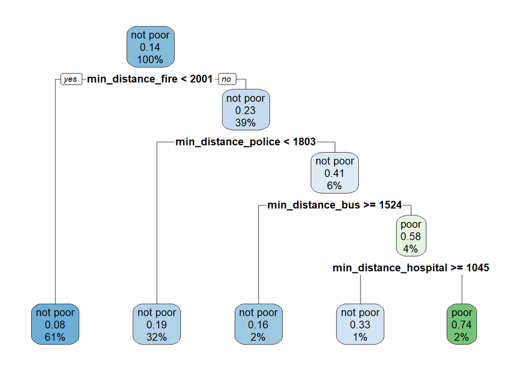

```r
# Decision tree

# create a recipe
med_rec <-
  recipe(formula = poor ~., data = med_train) %>%
  step_rm(block_id, ipm)

# create a cart model object
med_mod <-
  decision_tree() %>%
  set_engine(engine = "rpart") %>%
  set_mode(mode="classification")

med_dt_workflow <- workflow() %>%
  add_recipe(med_rec) %>%
  add_model(med_mod)

# fit the model
med_fit <- med_dt_workflow %>%
  fit(data = med_train)

# create a tree
rpart.plot::rpart.plot(x = med_fit$fit$fit$fit)
```

From the decision tree, we were unable to get the exact accuracy result, however we know that 2% predicted poor is far too low and this will not be a useful model compared to the other two.

#### Final fitting and prediction

```r
med_knn_final <- finalize_workflow(med_knn_workflow, parameters = med_knn_best)

med_knn_final_fit <- med_knn_final %>%
  fit(data = med_train)

med_knn_predictions <- med_knn_final_fit %>%
  predict(new_data = med_test) %>%
  bind_cols(med_test)

# Convert the truth column to a factor
med_knn_predictions$poor_factor <- factor(med_knn_predictions$poor)

med_knn_accuracy_final <- med_knn_predictions %>%
  yardstick::accuracy(truth = poor_factor, estimate = .pred_class)

med_knn_sensitivity_final <- med_knn_predictions %>%
  yardstick::sensitivity(truth = poor_factor, estimate = .pred_class)

med_knn_specificity_final <- med_knn_predictions %>%
  yardstick::specificity(truth = poor_factor, estimate = .pred_class)

med_knn_accuracy_final
```

```
# A tibble: 1 × 3
  .metric  .estimator .estimate
  <chr>    <chr>          <dbl>
1 accuracy binary         0.880
```

```r
med_knn_sensitivity_final
```

```
# A tibble: 1 × 3
  .metric     .estimator .estimate
  <chr>       <chr>          <dbl>
1 sensitivity binary         0.971
```

```r
med_knn_specificity_final
```

```
# A tibble: 1 × 3
  .metric     .estimator .estimate
  <chr>       <chr>          <dbl>
1 specificity binary         0.249
```

```r
med_implement_predict <- med_knn_final_fit %>%
  predict(data_med)
```

#### Final Interpretation - Classification

```r
med_sf <- med_sf %>%
  mutate(poor = ifelse(ipm >= 33, "poor", "not poor"))

med_compare <- bind_cols(
  med_sf,
  med_implement_predict)
```

[figure not shown]

```r
# Creating a comparison of total number of poor blocks.
actual_counts <- table(med_compare$poor)
predicted_counts <- table(med_compare$.pred_class)

plot_data <- data.frame(
  variable = rep(c("Actual", "Predicted"), each = 2),
  class = rep(c("poor", "not poor"), times = 2),
  count = c(actual_counts, predicted_counts)
)

ggplot(plot_data, aes(x = variable, y = count, fill = class)) +
  geom_bar(stat = "identity", position = "dodge") +
  labs(x = "Class", y = "Count", fill = "Poverty Class") +
  ggtitle("Comparison of Actual vs. Predicted Poverty Classes")
```

### Final Discussion of Results

In testing the different models using both classification and regression methods, we can see the models both require improvement in order to be useful in a policy-making context. This type of machine learning model is extremely valuable, if it can successfully predict poverty, because poverty measures are very costly and time consuming to determine as they usually rely on census data (which is only collected every 10 years and is extremely expensive). This type of machine learning model could help provide a gap to measure poverty without having to wait for new census data, and to be more cost-effective. However, we have seen that both our classification and regression models do not have sufficient predictive power to make them a reliable alternative to the current methods.

This suggests that we could take a few different approaches to strengthen the models in the future. One option would be to change the amenities used or to add additional amenities. We picked six amenities based on what the literature suggested would be most predictive, but this may have limited the predictive nature of the model by unintentionally leaving out other variables that may demonstrate greater differences between poor and non-poor blocks. We could use a combination of theory and testing to assess the predictive value of each of the relevant amenities to ensure they would help build a better model. We could also implement more powerful models with hyperparameter tuning.